# GSEA

Salam Khan

2022-04-27

# Loading the required libraries for GSE analysis.

```r
library(tidyverse)
```

```r
library(biomaRt)
library(msigdbr)
library(enrichplot)
library(DOSE)
library(clusterProfiler)
library(org.Hs.eg.db)
library(cowplot)
library(ReactomePA)
```

# Importing the differential expressed genes list.

```r
DGE_list <- read.csv("C:/Users/khan_/Desktop/GSEA/DEGs.csv", header = T)
head(DGE_list)
```

```
##         X    baseMean log2FoldChange     lfcSE     stat       pvalue
## 1   A4GNT    1.295282       1.940966 0.5489086 3.536045 4.061654e-04
## 2   AACSL    9.787842       1.282063 0.4110319 3.119133 1.813840e-03
## 3 AADACL3    8.114895       4.609892 0.8605778 5.356741 8.473653e-08
## 4   ABCA4   97.356071       1.336753 0.3659888 3.652442 2.597584e-04
## 5   ABCC2   69.696505       1.202348 0.3036574 3.959555 7.508970e-05
## 6   ABCC5 4337.983899       1.083403 0.2176559 4.977594 6.437944e-07
##           padj
## 1 1.079426e-03
## 2 4.230019e-03
## 3 4.163170e-07
## 4 7.153453e-04
## 5 2.276791e-04
## 6 2.775367e-06
```

# Renaming the first column as “Gene_symbol”

```r
colnames(DGE_list)[1] <- "Gene_symbol"
head(DGE_list)
```

```
##   Gene_symbol    baseMean log2FoldChange     lfcSE     stat       pvalue
## 1       A4GNT    1.295282       1.940966 0.5489086 3.536045 4.061654e-04
## 2       AACSL    9.787842       1.282063 0.4110319 3.119133 1.813840e-03
## 3     AADACL3    8.114895       4.609892 0.8605778 5.356741 8.473653e-08
## 4       ABCA4   97.356071       1.336753 0.3659888 3.652442 2.597584e-04
## 5       ABCC2   69.696505       1.202348 0.3036574 3.959555 7.508970e-05
## 6       ABCC5 4337.983899       1.083403 0.2176559 4.977594 6.437944e-07
##           padj
## 1 1.079426e-03
## 2 4.230019e-03
## 3 4.163170e-07
## 4 7.153453e-04
## 5 2.276791e-04
## 6 2.775367e-06
```

# Remember: You need to filter the gene list based on adjusted p-value or padj < 0.05. In the current list, the genes have been already screened by setting a cutoff. If you need to screen your list, then follow the below step;

# “DGE_list <- filter(DGE_list, DGE_list$padj < 0.05)”

# Annotating Gene symbols with Entrez gene ID in DGE_list file. For this step, we need to download Ensembl repository.

```r
ensembl = useMart("ensembl")
```

# Look at the different organisms libraries has been stored in Ensembl repository. We’ll be using “hsapiens_gene_ensembl” library because the gene symbols belong to human genome. It is Ok if some of the Gene_symbols misses Entrez IDs.

```r
listDatasets(ensembl)
```

```
##                            dataset
## 1     abrachyrhynchus_gene_ensembl
## 2         acalliptera_gene_ensembl
## 3       acarolinensis_gene_ensembl
## 4        acchrysaetos_gene_ensembl
## 5        acitrinellus_gene_ensembl
## 6        amelanoleuca_gene_ensembl
## 7          amexicanus_gene_ensembl
## 8          anancymaae_gene_ensembl
## 9          aocellaris_gene_ensembl
## 10           apercula_gene_ensembl
## 11     aplatyrhynchos_gene_ensembl
## 12      apolyacanthus_gene_ensembl
## 13    applatyrhynchos_gene_ensembl
## 14       atestudineus_gene_ensembl
```

[output cut: 633 more lines]

```r
ensembl = useDataset("hsapiens_gene_ensembl",mart=ensembl)
```

# Retrieving the IDs column and converting in to entrez gene ids.

```r
IDs <- getBM(attributes=c('external_gene_name','entrezgene_id'),
             filters = 'external_gene_name', values = DGE_list$Gene_symbol, mart = ensembl)
```

# Removing duplicate IDs from the files.

```r
IDs <- IDs[!duplicated(IDs$external_gene_name), ]
DGE_list <- DGE_list[!duplicated(DGE_list$Gene_symbol), ]
```

# Renaming the column name for merging with the dataset.

```r
names(IDs)[1] <- 'Gene_symbol'
DGE_list <- dplyr::inner_join(DGE_list, IDs, by="Gene_symbol")
```

# Preparing a gene lists file for enrichment analysis..

```r
genelist <- cbind(DGE_list$entrezgene_id, DGE_list$log2FoldChange)
colnames(genelist) <- c("ID", "Log2FC")
genelist <- as.data.frame(genelist)
geneList <- as.numeric(genelist[,2])
names(geneList) <- as.character(genelist[,1])
geneList <- sort(geneList, decreasing = TRUE)
head(geneList)
```

```
##      <NA> 100132399      9947       676      4109     51438
## 10.130595  9.470565  8.888965  8.528626  8.469522  8.417934
```

# This step is very crucial for setting a cutoff. I will choose value greater than absolute 1. You can play with this value to get an optimum results. If you need to know any further, then start learning “log2FC” of genes in transcriptomics profiling.

```r
gene <- names(geneList)[abs(geneList) > 1]
```

# GSEA using Mutational signature database (MsigDb) and getting H sapiens gene sets. The steps includes collecting from Msigdb for human, extraction of hallmarks info. and then retrieving gene sets for each hallmark.

```r
msigdbr_species()
```

```
## # A tibble: 20 x 2
##    species_name                    species_common_name
##    <chr>                           <chr>
##  1 Anolis carolinensis             Carolina anole, green anole
##  2 Bos taurus                      bovine, cattle, cow, dairy cow, domestic cat~
##  3 Caenorhabditis elegans          roundworm
##  4 Canis lupus familiaris          dog, dogs
##  5 Danio rerio                     leopard danio, zebra danio, zebra fish, zebr~
##  6 Drosophila melanogaster         fruit fly
##  7 Equus caballus                  domestic horse, equine, horse
##  8 Felis catus                     cat, cats, domestic cat
##  9 Gallus gallus                   bantam, chicken, chickens, Gallus domesticus
## 10 Homo sapiens                    human
## 11 Macaca mulatta                  rhesus macaque, rhesus macaques, Rhesus monk~
## 12 Monodelphis domestica           gray short-tailed opossum
## 13 Mus musculus                    house mouse, mouse
## 14 Ornithorhynchus anatinus        duck-billed platypus, duckbill platypus, pla~
## 15 Pan troglodytes                 chimpanzee
## 16 Rattus norvegicus               brown rat, Norway rat, rat, rats
## 17 Saccharomyces cerevisiae        baker's yeast, brewer's yeast, S. cerevisiae
## 18 Schizosaccharomyces pombe 972h- <NA>
## 19 Sus scrofa                      pig, pigs, swine, wild boar
## 20 Xenopus tropicalis              tropical clawed frog, western clawed frog
```

```r
m_df <- msigdbr(species = "Homo sapiens")
head(m_df, 2) %>% as.data.frame
```

```
##   gs_cat      gs_subcat        gs_name gene_symbol entrez_gene    ensembl_gene
## 1     C3 MIR:MIR_Legacy AAACCAC_MIR140       ABCC4       10257 ENSG00000125257
## 2     C3 MIR:MIR_Legacy AAACCAC_MIR140    ABRAXAS2       23172 ENSG00000165660
##   human_gene_symbol human_entrez_gene human_ensembl_gene  gs_id gs_pmid
## 1             ABCC4             10257    ENSG00000125257 M12609
## 2          ABRAXAS2             23172    ENSG00000165660 M12609
##   gs_geoid gs_exact_source gs_url
## 1
## 2
##                                                                                                                                                                                           gs_description
## 1 Genes having at least one occurence of the motif AAACCAC in their 3' untranslated region. The motif represents putative target (that is, seed match) of human mature miRNA hsa-miR-140 (v7.1 miRBase).
## 2 Genes having at least one occurence of the motif AAACCAC in their 3' untranslated region. The motif represents putative target (that is, seed match) of human mature miRNA hsa-miR-140 (v7.1 miRBase).
```

```r
m_df_H_t2g <- msigdbr(species = "Homo sapiens", category = "H") %>% dplyr::select(gs_name, entrez_gene)
head(m_df_H_t2g)
```

```
## # A tibble: 6 x 2
##   gs_name               entrez_gene
##   <chr>                       <int>
## 1 HALLMARK_ADIPOGENESIS          19
## 2 HALLMARK_ADIPOGENESIS       11194
## 3 HALLMARK_ADIPOGENESIS       10449
## 4 HALLMARK_ADIPOGENESIS          33
## 5 HALLMARK_ADIPOGENESIS          34
## 6 HALLMARK_ADIPOGENESIS          35
```

```r
collections <- msigdbr_collections()
m_df_H <- m_df[m_df$gs_cat=="H",]
head(m_df_H)
```

```
## # A tibble: 6 x 15
##   gs_cat gs_subcat gs_name gene_symbol entrez_gene ensembl_gene human_gene_symb~
##   <chr>  <chr>     <chr>   <chr>             <int> <chr>        <chr>
## 1 H      ""        HALLMA~ ABCA1                19 ENSG0000016~ ABCA1
## 2 H      ""        HALLMA~ ABCB8             11194 ENSG0000019~ ABCB8
## 3 H      ""        HALLMA~ ACAA2             10449 ENSG0000016~ ACAA2
## 4 H      ""        HALLMA~ ACADL                33 ENSG0000011~ ACADL
## 5 H      ""        HALLMA~ ACADM                34 ENSG0000011~ ACADM
## 6 H      ""        HALLMA~ ACADS                35 ENSG0000012~ ACADS
## # ... with 8 more variables: human_entrez_gene <int>, human_ensembl_gene <chr>,
## #   gs_id <chr>, gs_pmid <chr>, gs_geoid <chr>, gs_exact_source <chr>,
## #   gs_url <chr>, gs_description <chr>
```

```r
msigdbr_t2g = m_df_H %>% dplyr::select(gs_name, entrez_gene) %>% as.data.frame()
```

# Hallmarks enrichment analysis.

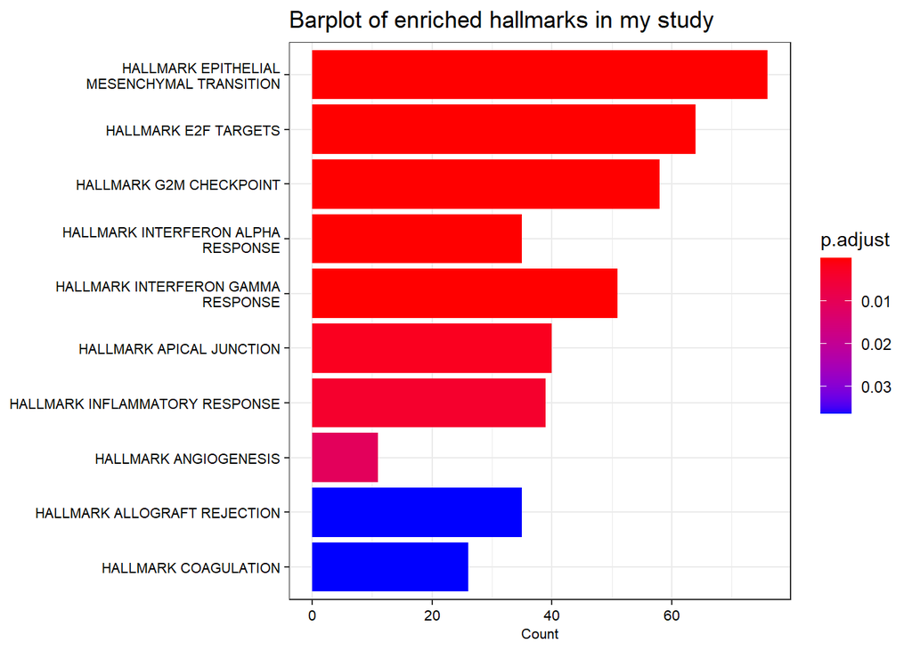

```r
hallmark_enricher <- enricher(gene = gene, TERM2GENE = msigdbr_t2g)
res_dot <- dotplot(hallmark_enricher, showCategory=10, font.size = 8, title = "Dotplot of enriched hallmarks in my study")
res_bar <- barplot(hallmark_enricher, showCategory=10, font.size = 8, title = "Barplot of enriched hallmarks in my study")
res_bar
```

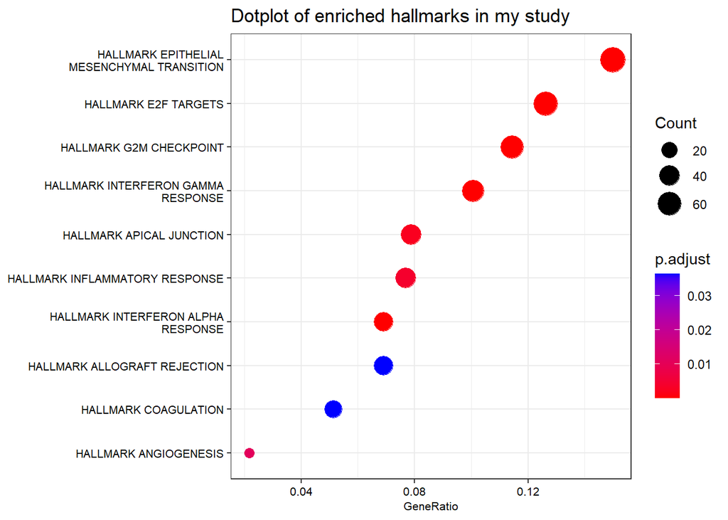

```r
res_dot
```

# GO enrichment analysis.

```r
GO_gse <- gseGO(geneList=geneList,
               ont ="ALL",#Specify if else; BP, MF, CC
               keyType = "ENTREZID",
               nPerm = 1000,
               minGSSize = 3,
               maxGSSize = 800,
               pvalueCutoff = 0.05,
               verbose = TRUE,
               OrgDb = org.Hs.eg.db,
               pAdjustMethod = "none")
```

```
## preparing geneSet collections...
```

```
## GSEA analysis...
```

```
## leading edge analysis...
```

```
## done...
```

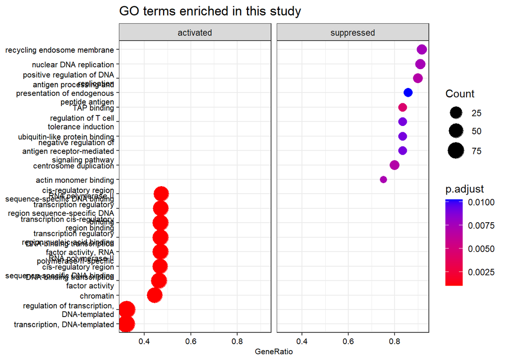

```r
dotplot(GO_gse, showCategory=10, font.size = 8, split=".sign", title = "GO terms enriched in this study") + facet_grid(.~.sign)
```

# Reactome pathways enrichment analysis for each study.

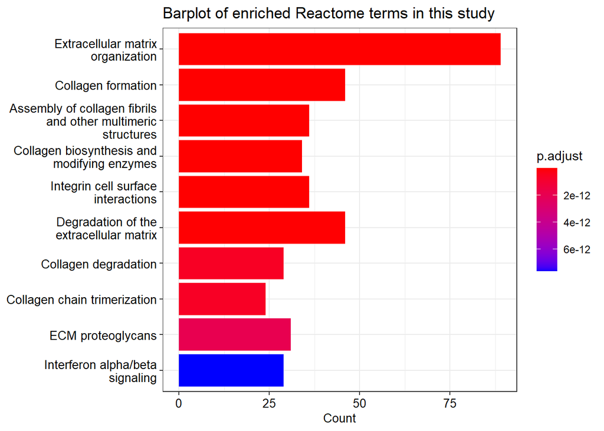

```r
reactome_enriched <- enrichPathway(gene=gene, pvalueCutoff=0.05, readable=T)
bar_reactome <- barplot(reactome_enriched, showCategory=10, font.size = 10,  title = "Barplot of enriched Reactome terms in this study")
dot_reactome <- dotplot(reactome_enriched, showCategory=10, font.size = 10, title = "Dotplot of enriched Reactome terms in this study")
bar_reactome
```

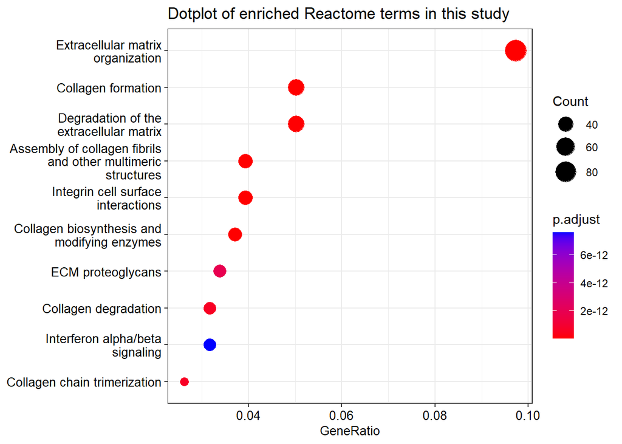

```r
dot_reactome
```